# Manipulação de Dados com Python

### Prof. Dr. Alex Fabianne de Paulo

## 4. Pré-processamento de dados

O pré-processamento de dados consiste em um amplo conjunto de técnicas para limpar, selecionar e transformar dados para melhorar a análise de mineração de dados. Leia as instruções passo a passo abaixo com atenção.

Na metodologia CRISP, visa a preparação dos dados disponíveis, que geralmente não estão dispostos em formato adequado, para a aplicação dos algoritmos de descoberta, análise e extração de conhecimento. Dentre as ações nesta etapa para produzir um conjunto de dados adequado aos algoritmos de mineração, estão:

```
- Seleção de dados
- Limpeza
- Transformação de dados
- Construção de dados: combinar múltiplas tabelas ou outras fontes
- Formatação dos dados
```

Esta mesma fase de preparação dos dados deve ser igualmente aplicada quando adotados outros métodos como KDD e SEMMA.

### Problemas de qualidade de dados

A baixa qualidade dos dados pode ter um efeito adverso na mineração de dados. Entre os problemas comuns de qualidade de dados estão ruído, valores discrepantes, valores ausentes e dados duplicados. Esta seção apresenta exemplos de código Python para aliviar alguns desses problemas de qualidade de dados. Começamos com um exemplo de conjunto de dados do repositório de aprendizado de máquina UCI contendo informações sobre pacientes com câncer de mama. Primeiro, faremos o download do conjunto de dados usando a função read_csv () do Pandas e exibiremos seus primeiros 5 pontos de dados.

Esta base de dados traz os seguintes dados:

- Espessura de aglomerado ('Clump Thickness')
- Uniformidade do tamanho da célula ('Uniformity of Cell Size')
- Uniformidade da forma celular ('Uniformity of Cell Shape')
- Adesão Marginal ('Marginal Adhesion')
- Tamanho Único de Célula Epitelial ('Single Epithelial Cell Size')
- Núcleos Nus ('Bare Nuclei')
- Cromatina Suave ('Bland Chromatin')
- Nucléolos normais ('Normal Nucleoli')
- Mitoses ('Mitoses')
- Classe ('Class')

**Código Python:**

```python
import pandas as pd
data = pd.read_csv('https://archive.ics.uci.edu/ml/machine-learning-databases/breast-cancer-wisconsin/breast-cancer-wisconsin.data', header=None)
data.columns = ['Sample code', 'Clump Thickness', 'Uniformity of Cell Size', 'Uniformity of Cell Shape',
                'Marginal Adhesion', 'Single Epithelial Cell Size', 'Bare Nuclei', 'Bland Chromatin',
                'Normal Nucleoli', 'Mitoses','Class']

data = data.drop(['Sample code'],axis=1)
print('Número de instâncias (registros) = %d' % (data.shape[0]))
print('Número de atributos = %d' % (data.shape[1]))
data.head()
```

```
Número de instâncias (registros) = 699
Número de atributos = 10
```

|  | Clump Thickness | Uniformity of Cell Size | Uniformity of Cell Shape | Marginal Adhesion | Single Epithelial Cell Size | Bare Nuclei | Bland Chromatin | Normal Nucleoli | Mitoses | Class |
| --- | --- | --- | --- | --- | --- | --- | --- | --- | --- | --- |
| 0 | 5 | 1 | 1 | 1 | 2 | 1 | 3 | 1 | 1 | 2 |
| 1 | 5 | 4 | 4 | 5 | 7 | 10 | 3 | 2 | 1 | 2 |
| 2 | 3 | 1 | 1 | 1 | 2 | 2 | 3 | 1 | 1 | 2 |
| 3 | 6 | 8 | 8 | 1 | 3 | 4 | 3 | 7 | 1 | 2 |
| 4 | 4 | 1 | 1 | 3 | 2 | 1 | 3 | 1 | 1 | 2 |

### Valores ausentes

É relativamente comum que um objeto não tenha um ou mais valores de atributo. Em alguns casos, as informações não foram coletadas; enquanto em outros casos, alguns atributos são inaplicáveis às instâncias de dados. Esta seção apresenta exemplos sobre as diferentes abordagens para lidar com valores ausentes.

De acordo com a descrição dos dados disponível em https://archive.ics.uci.edu/ml/datasets/breast+cancer+wisconsin+(original), os valores ausentes são codificados como '?' nos dados originais. Nossa primeira tarefa é converter os valores ausentes em NaNs. Podemos então contar o número de valores ausentes em cada coluna dos dados.

**Código Python:**

```python
import numpy as np

data = data.replace('?',np.NaN)

print('Número de instâncias = %d' % (data.shape[0]))
print('Número de atributos = %d' % (data.shape[1]))

print('Número de valores ausentes:')
for col in data.columns:
    print('\t%s: %d' % (col,data[col].isna().sum()))
```

```
Número de instâncias = 699
Número de atributos = 10
Número de valores ausentes:
	Clump Thickness: 0
	Uniformity of Cell Size: 0
	Uniformity of Cell Shape: 0
	Marginal Adhesion: 0
	Single Epithelial Cell Size: 0
	Bare Nuclei: 16
	Bland Chromatin: 0
	Normal Nucleoli: 0
	Mitoses: 0
	Class: 0
```

Observe que apenas a coluna 'Bare Nuclei' contém valores ausentes. No exemplo a seguir, os valores ausentes na coluna 'Bare Nuclei' são substituídos pelo valor mediano dessa coluna. Neste caso, foi usada a função fillna() para fazer o preenchimento. Os valores antes e depois da substituição são mostrados para um subconjunto dos pontos de dados.

**Código Python:**

```python
data2 = data['Bare Nuclei']

print('Antes da troca dos valores ausentes:')
print(data2[20:25])
data2 = data2.fillna(data2.median())

print('\nDepois da troca dos valores ausentes:')
print(data2[20:25])
```

```
Antes da troca dos valores ausentes:
20     10
21      7
22      1
23    NaN
24      1
Name: Bare Nuclei, dtype: object

Depois da troca dos valores ausentes:
20    10
21     7
22     1
23     1
24     1
Name: Bare Nuclei, dtype: object
```

Em vez de substituir os valores ausentes, outra abordagem comum é descartar os pontos de dados que contêm valores ausentes. Isso pode ser feito facilmente aplicando a função dropna () ao quadro de dados.

**Código Python:**

```python
print('Number of rows in original data = %d' % (data.shape[0]))

data2 = data.dropna()
print('Number of rows after discarding missing values = %d' % (data2.shape[0]))
```

```
Number of rows in original data = 699
Number of rows after discarding missing values = 683
```

#### Outros exemplos para tratar valores ausentes

```python
import numpy as np
import pandas as pd

df = pd.DataFrame({'A':[1,2,np.nan],
                  'B':[5,np.nan,np.nan],
                  'C':[1,2,3]})
```

```python
df
```

|  | A | B | C |
| --- | --- | --- | --- |
| 0 | 1.0 | 5.0 | 1 |
| 1 | 2.0 | NaN | 2 |
| 2 | NaN | NaN | 3 |

```python
df.dropna()         # pega apenas a linha que não tem dados ausentes
```

|  | A | B | C |
| --- | --- | --- | --- |
| 0 | 1.0 | 5.0 | 1 |

```python
df.dropna(axis=1)    # pega apenas a coluna que não tem dados ausentes
```

|  | C |
| --- | --- |
| 0 | 1 |
| 1 | 2 |
| 2 | 3 |

```python
df.fillna(value='Conteúdo')   # subtitui os valores ausentes por conteúdo
```

|  | A | B | C |
| --- | --- | --- | --- |
| 0 | 1 | 5 | 1 |
| 1 | 2 | Conteúdo | 2 |
| 2 | Conteúdo | Conteúdo | 3 |

```python
df['A'].fillna(value=df['A'].mean())   # subtitui os valores ausentes pela média dos valores da coluna
```

```
0    1.0
1    2.0
2    1.5
Name: A, dtype: float64
```

### Outliers

Outliers são instâncias de dados com características consideravelmente diferentes do resto do conjunto de dados. No exemplo abaixo, desenharemos um boxplot para identificar as colunas na tabela que contêm outliers. Observe que os valores em todas as colunas (exceto para 'Núcleos nus') são originalmente armazenados como 'int64', enquanto os valores na coluna 'Bare Nuclei' são armazenados como objetos de string (uma vez que a coluna contém inicialmente strings como '?' para representar valores ausentes). Portanto, devemos converter a coluna em valores numéricos antes de criar o boxplot. Caso contrário, a coluna não será exibida ao desenhar o boxplot.

**Código Python:**

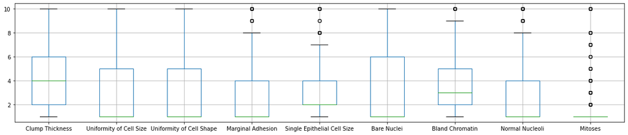

```python
%matplotlib inline

data2 = data.drop(['Class'],axis=1)
data2['Bare Nuclei'] = pd.to_numeric(data2['Bare Nuclei'])
data2.boxplot(figsize=(20,4))
```

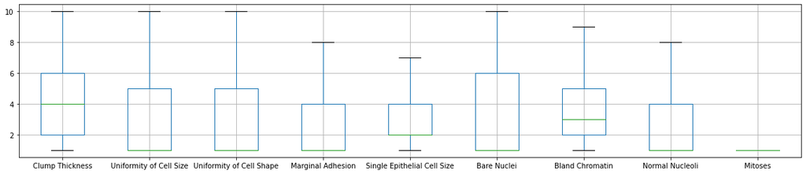

```python
# o parâmetro vert da função bloxplot define se o bloxplot será vertical (vert=1) ou horizontal (vert=0)
# já o parâmetro showFliers oculta (0) ou mostra (1) os pontos outliers em um boxplot

data2.boxplot(figsize=(20,4), vert=1, showfliers=0)
```

Os boxplots sugerem que apenas 5 das colunas (Marginal Adhesion, Single Epithetial Cell Size, Bland Cromatin, Normal Nucleoli, and Mitoses) contêm valores anormalmente elevados. Para descartar os valores discrepantes, podemos calcular o Z-score para cada atributo e remover as instâncias que contêm atributos com Z-score anormalmente alto ou baixo (por exemplo, se Z> 3 ou Z <= -3).

** Lembrando que o escore Z (também conhecido por Teste Z ou Escore Padronizado) refere-se ao quanto uma medida se afasta da média em termos de Desvios Padrão. Quando o escore Z é positivo, indica que o dado está acima da média e quando o mesmo é negativo, significa que o dado está abaixo da média. Seus valores oscilam entre -3 < Z < +3 e isto corresponde a 99,72% da área sob a curva da Distribuição Normal.

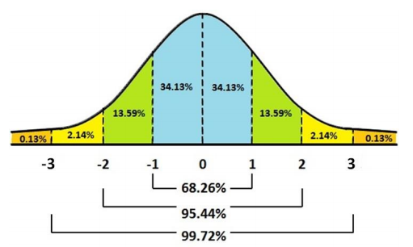

O código a seguir mostra os resultados da padronização das colunas de dados. Observe que os valores ausentes (NaN) não são afetados pelo processo de padronização.

**Código Python:**

```python
Z = (data2-data2.mean())/data2.std()
Z[20:25]
```

|  | Clump Thickness | Uniformity of Cell Size | Uniformity of Cell Shape | Marginal Adhesion | Single Epithelial Cell Size | Bare Nuclei | Bland Chromatin | Normal Nucleoli | Mitoses |
| --- | --- | --- | --- | --- | --- | --- | --- | --- | --- |
| 20 | 0.917080 | -0.044070 | -0.406284 | 2.519152 | 0.805662 | 1.771569 | 0.640688 | 0.371049 | 1.405526 |
| 21 | 1.982519 | 0.611354 | 0.603167 | 0.067638 | 1.257272 | 0.948266 | 1.460910 | 2.335921 | -0.343666 |
| 22 | -0.503505 | -0.699494 | -0.742767 | -0.632794 | -0.549168 | -0.698341 | -0.589645 | -0.611387 | -0.343666 |
| 23 | 1.272227 | 0.283642 | 0.603167 | -0.632794 | -0.549168 | NaN | 1.460910 | 0.043570 | -0.343666 |
| 24 | -1.213798 | -0.699494 | -0.742767 | -0.632794 | -0.549168 | -0.698341 | -0.179534 | -0.611387 | -0.343666 |

**Código Python:**

```python
print('Número de linhas antes de descartar os outliers = %d' % (Z.shape[0]))

Z2 = Z.loc[((Z > -3).sum(axis=1)==9) & ((Z <= 3).sum(axis=1)==9),:]
print('Número de linhas após descartar os outliers = %d' % (Z2.shape[0]))

Z2
```

```
Número de linhas antes de descartar os outliers = 699
Número de linhas após descartar os outliers = 632
```

|  | Clump Thickness | Uniformity of Cell Size | Uniformity of Cell Shape | Marginal Adhesion | Single Epithelial Cell Size | Bare Nuclei | Bland Chromatin | Normal Nucleoli | Mitoses |
| --- | --- | --- | --- | --- | --- | --- | --- | --- | --- |
| 0 | 0.206788 | -0.699494 | -0.742767 | -0.632794 | -0.549168 | -0.698341 | -0.179534 | -0.611387 | -0.343666 |
| 1 | 0.206788 | 0.283642 | 0.266684 | 0.768071 | 1.708882 | 1.771569 | -0.179534 | -0.283909 | -0.343666 |
| 2 | -0.503505 | -0.699494 | -0.742767 | -0.632794 | -0.549168 | -0.423907 | -0.179534 | -0.611387 | -0.343666 |
| 3 | 0.561934 | 1.594490 | 1.612618 | -0.632794 | -0.097558 | 0.124962 | -0.179534 | 1.353485 | -0.343666 |
| 4 | -0.148359 | -0.699494 | -0.742767 | 0.067638 | -0.549168 | -0.698341 | -0.179534 | -0.611387 | -0.343666 |
| ... | ... | ... | ... | ... | ... | ... | ... | ... | ... |
| 694 | -0.503505 | -0.699494 | -0.742767 | -0.632794 | -0.097558 | -0.423907 | -0.999756 | -0.611387 | -0.343666 |
| 695 | -0.858651 | -0.699494 | -0.742767 | -0.632794 | -0.549168 | -0.698341 | -0.999756 | -0.611387 | -0.343666 |
| 696 | 0.206788 | 2.249915 | 2.285586 | 0.067638 | 1.708882 | -0.149472 | 1.871021 | 2.335921 | 0.239398 |
| 697 | -0.148359 | 1.594490 | 0.939651 | 0.417854 | -0.097558 | 0.124962 | 2.691243 | 1.026006 | -0.343666 |
| 698 | -0.148359 | 1.594490 | 1.612618 | 0.768071 | 0.354052 | 0.399397 | 2.691243 | 0.371049 | -0.343666 |

632 rows × 9 columns

### Dados duplicados

Alguns conjuntos de dados, especialmente aqueles obtidos pela fusão de várias fontes de dados, podem conter duplicatas. O termo *deduplication* (numa tradução livre, "desduplicação") costuma ser usado para se referir ao processo de lidar com problemas de dados duplicados.

**Código Python:**

```python
dups = data.duplicated()
print('Número de linhas duplicadas = %d' % (dups.sum()))
data.loc[[11,28]]
```

```
Número de linhas duplicadas = 236
```

|  | Clump Thickness | Uniformity of Cell Size | Uniformity of Cell Shape | Marginal Adhesion | Single Epithelial Cell Size | Bare Nuclei | Bland Chromatin | Normal Nucleoli | Mitoses | Class |
| --- | --- | --- | --- | --- | --- | --- | --- | --- | --- | --- |
| 11 | 2 | 1 | 1 | 1 | 2 | 1 | 2 | 1 | 1 | 2 |
| 28 | 2 | 1 | 1 | 1 | 2 | 1 | 2 | 1 | 1 | 2 |

```python
dups
```

```
0      False
1      False
2      False
3      False
4      False
       ...
694    False
695     True
696    False
697    False
698    False
Length: 699, dtype: bool
```

A função duplicated() retornará um array booleano que indica se cada linha é uma duplicata de uma linha anterior na tabela. Os resultados sugerem que há 236 linhas duplicadas no conjunto de dados de câncer de mama. Por exemplo, a instância com índice de linha 11 tem valores de atributo idênticos à instância com índice de linha 28. Embora essas linhas duplicadas possam corresponder a amostras para diferentes indivíduos, neste exemplo hipotético, assumimos que as duplicatas são amostras retiradas do mesmo indivíduo e ilustrar abaixo como remover as linhas duplicadas.

**Código Python:**

```python
print('Número de linhas antes de descartar duplicatas = %d' % (data.shape[0]))
data2 = data.drop_duplicates()
print('Número de linhas após de descartar duplicatas = %d' % (data2.shape[0]))
```

```
Número de linhas antes de descartar duplicatas = 699
Número de linhas após de descartar duplicatas = 463
```

### Agregação

A agregação de dados é uma tarefa de pré-processamento em que os valores de dois ou mais objetos são combinados em um único objeto. A motivação para a agregação inclui (1) reduzir o tamanho dos dados a serem processados, (2) alterar a granularidade da análise (de escala fina para escala mais grosseira) e (3) melhorar a estabilidade dos dados.

No exemplo abaixo, usaremos os dados da série temporal de precipitação diária para uma estação meteorológica localizada no Aeroporto Metro de Detroit. Os dados brutos foram obtidos no site Climate Data Online (https://www.ncdc.noaa.gov/cdo-web/). A série temporal da precipitação diária será comparada com seus valores mensais.

O código a seguir carregará os dados da série temporal de precipitação e desenhará um gráfico de linha de sua série temporal diária.

**Código Python:**

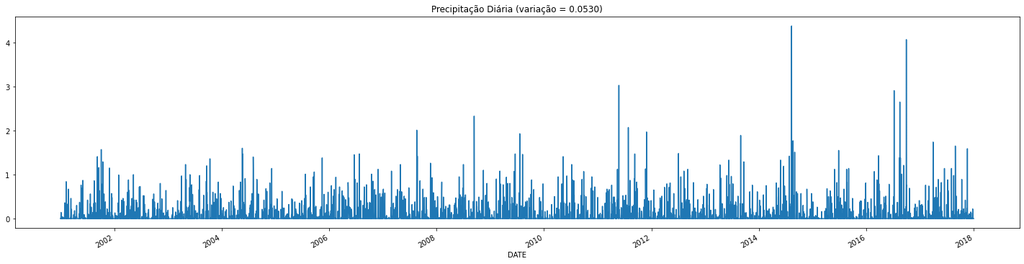

```python
daily = pd.read_csv('DTW_prec.csv', header='infer')
daily.index = pd.to_datetime(daily['DATE'])
daily = daily['PRCP']
ax = daily.plot(kind='line',figsize=(25,6))
ax.set_title('Precipitação Diária (variação = %.4f)' % (daily.var()))
```

Observe que as séries temporais diárias parecem ser bastante caóticas e variam significativamente de uma etapa de tempo para outra. As séries temporais podem ser agrupadas e agregadas por mês para obter os valores totais de precipitação mensal. A série temporal resultante parece variar mais suavemente em comparação com a série temporal diária.

**Código Python:**

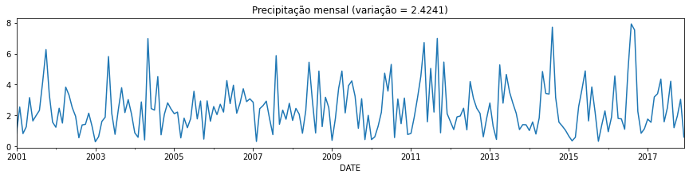

```python
monthly = daily.groupby(pd.Grouper(freq='M')).sum()
ax = monthly.plot(kind='line',figsize=(15,3))
ax.set_title('Precipitação mensal (variação = %.4f)' % (monthly.var()))
```

No exemplo abaixo, as séries temporais de precipitação diária são agrupadas e agregadas por ano para obter os valores de precipitação anual.

**Código Python:**

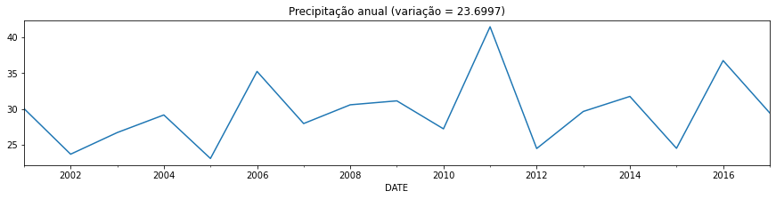

```python
annual = daily.groupby(pd.Grouper(freq='Y')).sum()
ax = annual.plot(kind='line',figsize=(15,3))
ax.set_title('Precipitação anual (variação = %.4f)' % (annual.var()))
```

#### Outros exemplos para fazer agregação

```python
import pandas as pd
# Cria um DataFrame
var = {'Empresa':['Google','Google','Microsoft','Microsoft','Nubank','Nubank'],
       'Nome':['Samual','Charles','Amelia','Vanessa','Carlos','Sara'],
       'Venda':[2000,1200,3400,1240,2430,3500]}
```

```python
df = pd.DataFrame(var)
df
```

|  | Empresa | Nome | Venda |
| --- | --- | --- | --- |
| 0 | Google | Samual | 2000 |
| 1 | Google | Charles | 1200 |
| 2 | Microsoft | Amelia | 3400 |
| 3 | Microsoft | Vanessa | 1240 |
| 4 | Nubank | Carlos | 2430 |
| 5 | Nubank | Sara | 3500 |

Agora, deve-se usar o método .group by() para agregar as linhas em um conjunto, com base em um nome de coluna. Por exemplo, agrupar com base na empresa. Isso criará um objeto DataFrameGroupBy. Depois, deve-se salvar esta este objeto em uma nova variável.

```python
df.groupby('Empresa')
```

```
<pandas.core.groupby.generic.DataFrameGroupBy object at 0x0000016CE493F910>
```

```python
agrega_empresa = df.groupby("Empresa")
```

Agora, é chamar métodos agregados do objeto:

```python
agrega_empresa.mean()   # poderia usar tbm df.groupby('Empresa').mean()
```

| Empresa | Venda |
| --- | --- |
| Google | 1600 |
| Microsoft | 2320 |
| Nubank | 2965 |

```python
agrega_empresa.std()   # pode usar outras funções de agregação min(), max(), count()
```

| Empresa | Venda |
| --- | --- |
| Google | 565.685425 |
| Microsoft | 1527.350647 |
| Nubank | 756.604256 |

```python
agrega_empresa.describe()   # retorna diversas estatísticas descritivas ao mesmo tempo
```

| Empresa | Venda count | Venda mean | Venda std | Venda min | Venda 25% | Venda 50% | Venda 75% | Venda max |
| --- | --- | --- | --- | --- | --- | --- | --- | --- |
| Google | 2.0 | 1600.0 | 565.685425 | 1200.0 | 1400.0 | 1600.0 | 1800.0 | 2000.0 |
| Microsoft | 2.0 | 2320.0 | 1527.350647 | 1240.0 | 1780.0 | 2320.0 | 2860.0 | 3400.0 |
| Nubank | 2.0 | 2965.0 | 756.604256 | 2430.0 | 2697.5 | 2965.0 | 3232.5 | 3500.0 |

```python
agrega_empresa.describe().transpose()
```

|  | Empresa | Google | Microsoft | Nubank |
| --- | --- | --- | --- | --- |
| Venda | count | 2.000000 | 2.000000 | 2.000000 |
|  | mean | 1600.000000 | 2320.000000 | 2965.000000 |
|  | std | 565.685425 | 1527.350647 | 756.604256 |
|  | min | 1200.000000 | 1240.000000 | 2430.000000 |
|  | 25% | 1400.000000 | 1780.000000 | 2697.500000 |
|  | 50% | 1600.000000 | 2320.000000 | 2965.000000 |
|  | 75% | 1800.000000 | 2860.000000 | 3232.500000 |
|  | max | 2000.000000 | 3400.000000 | 3500.000000 |

```python
agrega_empresa.describe().transpose()['Nubank']
```

```
Venda  count       2.000000
       mean     2965.000000
       std       756.604256
       min      2430.000000
       25%      2697.500000
       50%      2965.000000
       75%      3232.500000
       max      3500.000000
Name: Nubank, dtype: float64
```

### Amostragem

A amostragem é uma abordagem comumente usada para facilitar:

- a redução de dados para análise exploratória de dados e algoritmos de escalonamento para aplicativos de big data
- a quantificação de incertezas devido a distribuições de dados variáveis.

Existem vários métodos disponíveis para amostragem de dados, como amostragem sem substituição, onde cada instância selecionada é removida do conjunto de dados, e amostragem com substituição, onde cada instância selecionada não é removida, permitindo assim que seja selecionada mais de uma vez na amostra.

No exemplo abaixo, aplicaremos a amostragem com substituição e sem substituição ao conjunto de dados de câncer de mama obtido do repositório de aprendizado de máquina UCI. Inicialmente, exibimos os primeiros cinco registros da tabela.

**Código Python:**

```python
data.head()
```

|  | Clump Thickness | Uniformity of Cell Size | Uniformity of Cell Shape | Marginal Adhesion | Single Epithelial Cell Size | Bare Nuclei | Bland Chromatin | Normal Nucleoli | Mitoses | Class |
| --- | --- | --- | --- | --- | --- | --- | --- | --- | --- | --- |
| 0 | 5 | 1 | 1 | 1 | 2 | 1 | 3 | 1 | 1 | 2 |
| 1 | 5 | 4 | 4 | 5 | 7 | 10 | 3 | 2 | 1 | 2 |
| 2 | 3 | 1 | 1 | 1 | 2 | 2 | 3 | 1 | 1 | 2 |
| 3 | 6 | 8 | 8 | 1 | 3 | 4 | 3 | 7 | 1 | 2 |
| 4 | 4 | 1 | 1 | 3 | 2 | 1 | 3 | 1 | 1 | 2 |

No código a seguir, uma amostra de tamanho 5 é selecionada aleatoriamente (sem substituição) dos dados originais.

**Código Python:**

```python
sample = data.sample(n=5)
sample
```

|  | Clump Thickness | Uniformity of Cell Size | Uniformity of Cell Shape | Marginal Adhesion | Single Epithelial Cell Size | Bare Nuclei | Bland Chromatin | Normal Nucleoli | Mitoses | Class |
| --- | --- | --- | --- | --- | --- | --- | --- | --- | --- | --- |
| 315 | 4 | 6 | 5 | 6 | 7 | NaN | 4 | 9 | 1 | 2 |
| 496 | 1 | 1 | 1 | 1 | 1 | 1 | 1 | 1 | 1 | 2 |
| 246 | 8 | 10 | 10 | 8 | 5 | 10 | 7 | 8 | 1 | 4 |
| 446 | 1 | 1 | 1 | 1 | 2 | 1 | 1 | 1 | 1 | 2 |
| 655 | 3 | 1 | 1 | 1 | 2 | 1 | 2 | 1 | 1 | 2 |

No próximo exemplo, selecionamos aleatoriamente 1% dos dados (sem substituição) e exibimos as amostras selecionadas. O argumento random_state da função especifica o valor da semente do gerador de número aleatório.

**Código Python:**

```python
sample = data.sample(frac=0.01, random_state=1)
sample
```

|  | Clump Thickness | Uniformity of Cell Size | Uniformity of Cell Shape | Marginal Adhesion | Single Epithelial Cell Size | Bare Nuclei | Bland Chromatin | Normal Nucleoli | Mitoses | Class |
| --- | --- | --- | --- | --- | --- | --- | --- | --- | --- | --- |
| 584 | 5 | 1 | 1 | 6 | 3 | 1 | 1 | 1 | 1 | 2 |
| 417 | 1 | 1 | 1 | 1 | 2 | 1 | 2 | 1 | 1 | 2 |
| 606 | 4 | 1 | 1 | 2 | 2 | 1 | 1 | 1 | 1 | 2 |
| 349 | 4 | 2 | 3 | 5 | 3 | 8 | 7 | 6 | 1 | 4 |
| 134 | 3 | 1 | 1 | 1 | 3 | 1 | 2 | 1 | 1 | 2 |
| 502 | 4 | 1 | 1 | 2 | 2 | 1 | 2 | 1 | 1 | 2 |
| 117 | 4 | 5 | 5 | 10 | 4 | 10 | 7 | 5 | 8 | 4 |

Por fim, realizamos uma amostragem com reposição para criar uma amostra cujo tamanho é igual a 1% de todos os dados. Você poderá observar instâncias duplicadas na amostra aumentando o tamanho da amostra.

**Código Python:**

```python
sample = data.sample(frac=0.01, replace=True, random_state=1)
sample
```

|  | Clump Thickness | Uniformity of Cell Size | Uniformity of Cell Shape | Marginal Adhesion | Single Epithelial Cell Size | Bare Nuclei | Bland Chromatin | Normal Nucleoli | Mitoses | Class |
| --- | --- | --- | --- | --- | --- | --- | --- | --- | --- | --- |
| 37 | 6 | 2 | 1 | 1 | 1 | 1 | 7 | 1 | 1 | 2 |
| 235 | 3 | 1 | 4 | 1 | 2 | NaN | 3 | 1 | 1 | 2 |
| 72 | 1 | 3 | 3 | 2 | 2 | 1 | 7 | 2 | 1 | 2 |
| 645 | 3 | 1 | 1 | 1 | 2 | 1 | 2 | 1 | 1 | 2 |
| 144 | 2 | 1 | 1 | 1 | 2 | 1 | 2 | 1 | 1 | 2 |
| 129 | 1 | 1 | 1 | 1 | 10 | 1 | 1 | 1 | 1 | 2 |
| 583 | 3 | 1 | 1 | 1 | 2 | 1 | 1 | 1 | 1 | 2 |

### Discretização

A discretização é uma etapa de pré-processamento de dados que costuma ser usada para transformar um atributo de valor contínuo em um atributo categórico. O exemplo abaixo ilustra dois métodos simples, mas amplamente utilizados de discretização não supervisionada (largura igual e profundidade igual) aplicados ao atributo 'Espessura do aglomerado' ('Clump Thickness') do conjunto de dados de câncer de mama.

Primeiro, traçamos um histograma que mostra a distribuição dos valores dos atributos. A função value_counts() também pode ser aplicada para contar a frequência de cada valor de atributo.

**Código Python:**

```
1     145
5     130
3     108
4      80
10     69
2      50
8      46
6      34
7      23
9      14
Name: Clump Thickness, dtype: int64
```

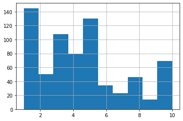

```python
data['Clump Thickness'].hist(bins=10)
data['Clump Thickness'].value_counts(sort=True)
```

Para o método de largura equivalente, podemos aplicar a função cut() para discretizar o atributo em 4 caixas de larguras de intervalo semelhantes. A função value_counts() pode ser usada para determinar o número de instâncias em cada compartimento.

**Código Python:**

```python
bins = pd.cut(data['Clump Thickness'],4)
bins.value_counts(sort=False)
```

```
(0.991, 3.25]    303
(3.25, 5.5]      210
(5.5, 7.75]       57
(7.75, 10.0]     129
Name: Clump Thickness, dtype: int64
```

Para o método de frequência equivalente, a função qcut() pode ser usada para particionar os valores em 4 compartimentos de modo que cada compartimento tenha quase o mesmo número de instâncias.

**Código Python:**

```python
bins = pd.qcut(data['Clump Thickness'],4)
bins.value_counts(sort=False)
```

```
(0.999, 2.0]    195
(2.0, 4.0]      188
(4.0, 6.0]      164
(6.0, 10.0]     152
Name: Clump Thickness, dtype: int64
```